# Homework_10

Madelynn Edwards

2024-04-03

# For Loops and Randomization Tests

#### 1. Using a `for loop`, write a function to calculate the number of zeroes in a numeric vector. Before entering the loop, set up a `counter` variable `counter <- 0`. Inside the loop, add 1 to counter each time you have a zero in the vector. Finally, use `return(counter)` for the output.

```r
z <- rbinom(30, 1, 0.5)
z
```

```
##  [1] 1 1 0 1 1 0 0 0 0 1 1 1 0 1 0 1 0 1 1 0 0 0 1 0 0 1 0 0 1 0
```

```r
counter <- 0

for (i in seq_along(z)){
    if(z[i] == 0) {
      counter <- counter + 1
    }
  }
print(counter)
```

```
## [1] 16
```

#### 2. Use subsetting instead of a loop to rewrite the function as a single line of code.

```r
length(z[z==0])
```

```
## [1] 16
```

#### 3. Write a function that takes as input two integers representing the number of rows and columns in a matrix. The output is a matrix of these dimensions in which each element is the product of the row number x the column number.

```r
matrixfunction <- function(row = 2, col = 3){
    df <- expand.grid(x=1:row, y=1:col)
    print(df)
    mvec <- df$x*df$y
    #print(mvec)
    matrix <- matrix(mvec, nrow=row, ncol=col)
    print(matrix)
}

matrixfunction()
```

```
##   x y
## 1 1 1
## 2 2 1
## 3 1 2
## 4 2 2
## 5 1 3
## 6 2 3
##      [,1] [,2] [,3]
## [1,]    1    2    3
## [2,]    2    4    6
```

#### 4. Now let’s practice calling custom functions within a for loops. Use the code from previous lectures on loops and functions to complete the following steps:

I had some trouble with this question!

#### a. Simulate a dataset with 3 groups of data, each group drawn from a distribution with a different mean. The final data frame should have 1 column for group and 1 column for the response variable.

```r
n <- 15 # number of observations in each variable
var <- c("var1", "var2", "var3") # including three variable groups into the var object

data <- data.frame(matrix(nrow= n, ncol=2)) # make dataframe that will have two columns and 15 rows per variable
var_df <- NULL # empty object to assign temporary dataframe to

for(i in 1:length(var)) {
  data[1] <- rep(var[i], each=n) # repeating var (starting with var1) for first column
  data[2] <- rnorm(n=n, mean=runif(1)) # generating 15 random numbers for second column of dataframe, each with different mean for each var
  var_df <- rbind(var_df,data) # binding data in one dataframe
}

str(var_df)
```

```
## 'data.frame':    45 obs. of  2 variables:
##  $ X1: chr  "var1" "var1" "var1" "var1" ...
##  $ X2: num  -0.236 -0.351 1.835 0.724 -1.476 ...
```

#### b. Write a custom function that 1) reshuffles the response variable, and 2) calculates the mean of each group in the reshuffled data. Store the means in a vector of length 3.

```r
library(dplyr)
reshufflefunc <- function(n=15, v=3) {
  var_df[2] <- sample(var_df$X2, replace = FALSE) # reshuffling column data
  group_mean<- aggregate(x= var_df$X2, by = list(var_df$X1), FUN = mean)

  mean_vec <- group_mean$x # converting to vector
print(mean_vec)

}

reshufflefunc()
```

```
## [1] -0.09219274  0.32947752  0.49237169
```

#### c.Use a for loop to repeat the function in b 100 times. Store the results in a data frame that has 1 column indicating the replicate number and 1 column for each new group mean, for a total of 4 columns.

```r
rep <- 1:100
df_rep <- NULL
mean_vec <- NULL

for (i in 1:length(rep)) {
  mean_vec <- reshufflefunc()
  var_df[3] <- mean_vec
  var_df[4] <- i
  df_rep <- rbind(df_rep, var_df)
}
```

```
## [1] 0.1116536 0.2875698 0.3304331
## [1]  0.51986138 -0.05956103  0.26935611
## [1] -0.08166348  0.33544294  0.47587701
## [1] 0.331359641 0.391328036 0.006968787
## [1] 0.05127103 0.58578364 0.09260180
## [1] -0.2392034  0.8119848  0.1568750
## [1] 0.04223153 0.02886266 0.65856227
## [1]  0.69200780  0.13399867 -0.09635001
## [1] -0.01536468 -0.01570111  0.76072226
## [1] 0.03857038 0.21018156 0.48090453
## [1] 0.1695067 0.1363974 0.4237524
## [1]  0.14176221  0.63065919 -0.04276494
## [1]  0.5525815 -0.0408387  0.2179137
## [1]  0.3032310 -0.3189771  0.7454026
## [1]  0.4315640  0.4573164 -0.1592239
```

[output cut: 85 more lines]

```r
str(df_rep)
```

```
## 'data.frame':    4500 obs. of  4 variables:
##  $ X1: chr  "var1" "var1" "var1" "var1" ...
##  $ X2: num  -0.236 -0.351 1.835 0.724 -1.476 ...
##  $ V3: num  0.112 0.288 0.33 0.112 0.288 ...
##  $ V4: int  1 1 1 1 1 1 1 1 1 1 ...
```

#### d. Use qplot() to create a histogram of the means for each reshuffled group. Or, if you want a challenge, use ggplot() to overlay all 3 histograms in the same figure. How do the distributions of reshuffled means compare to the original means?

This doesnt seem right…

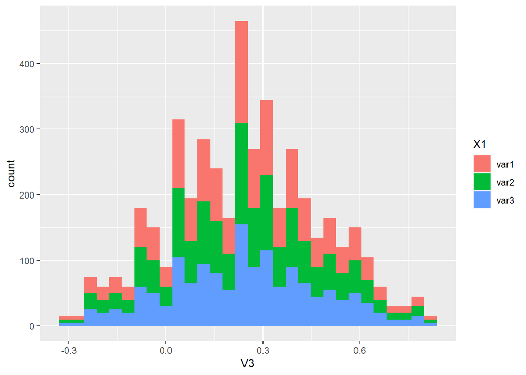

```r
library(ggplot2)


plot <- ggplot(data = df_rep)+
  aes(x=V3, fill=X1)+
  geom_histogram()
plot
```